# BRCA2116 cohort

Mik Black

2022-09-18

```r
setwd("~/Postgrad/Honours")
library(dplyr)
library(survival)
```

Load cohort data:

```r
load('brca2116_dataset.RData')
```

Two objects:

- `expDat`: normalised gene expression data (on log scale) from 2116 tumours Affymetrix arrays). Probe data have been collapsed to 12403 genes (gene symbols used as IDs).
- `sampleData`: data relating to each sample:
  - **dataSet**: data set that the sample came from.
  - **sampleNames**: sample ID
  - **LN.status**: Lymph Node status (LN+/LN-)
  - **ER.status**: Estrogen Receptor status (ER+/ER-)
  - **PgR.status**: Progesterone Receptor status (PgR+/PgR-)
  - **Grade**: Tumour Grade (G1/G2/G3)
  - **Size**: Tumour size (mm)
  - **Age**: Patient age at diagnosis (years)
  - **Subtype**: Molecular subtype (Basal/ClaudinLow/Her2/LumA/LumB/Normal/NoSubtype)
  - **EndocrineTrt**: Did patient recieve endocrine therapy? (No = 0, Yes = 1)
  - **ChemoTrt**: Did patient recieve chemotherapy? (No = 0, Yes = 1)
  - **dfsTime**: Disease-free survival time (years)
  - **dfsEvent**: Disease-free survival event (non-recurence=0, recurence=1)
  - **dmfsTime**: Distant-metastasis-free survival time (years)
  - **dmfsEvent**: Distant-metastasis-free survival event (no metastasis=0, metastasis=1)
  - **dssTime**: Disease-specific survival time (years)
  - **dssEvent**: Disease-specific survival event (alive=0, dead=1)

HIgh or low IQSEC2 include ER+ and ER- samples:

```r
#IQSEC2high = IQSEC2[IQSEC2>2.927,]
#IQSEC2low = IQSEC2[IQSEC2<2.927,]

#ifelse = ifelse(IQSEC2<2.927,1,2)


#iqp = expDat["IQSEC2",sampleData$ER.status=="ER+"]
#iqn = expDat["IQSEC2",sampleData$ER.status=="ER-"]

#iqp = na.omit(iqp)
#iqn = na.omit(iqn)

#iqp = as.data.frame(iqp)
#iqp = as.numeric(iqp)
#iqp

#iqp = as.matrix(iqp)
#colnames(iqp) = "IQSEC2 expression"
#median(iqp)
#dim(iqp)

#sampleNamesnona = sampleData[sampleData$ER.status=="ER+",2]
#sampleNamesnona = na.omit(sampleNamesnona)
#length(sampleNamesnona)

sampleDatap = sampleData[(sampleData$ER.status=="ER+" & sampleData$EndocrineTrt==1) ,]
sampleDatan = sampleData[(sampleData$ER.status=="ER-" & sampleData$PgR.status=="PgR-" & sampleData$EndocrineTrt==1),]
#dim(sampleDatan)
#sampleDatao = sampleDatap[(na.omit(sampleDatap$ER.status)),]
#sampleDatao = as.matrix(na.omit(sampleDatap$ER.status))
#View(sampleDatao)
#class(sampleDatao)

#expDatp = expDat[,(sampleDatap$sampleNames)]
#View(expDatp)

#iqpif = ifelse(iqp > median(iqp), 1,0)
#table(iqpif)
#expDatp["IQSEC2",]
#mean(expDatp["IQSEC2",])
#median(expDatp["IQSEC2",])

#iqpp = expDatp["IQSEC2",]
#iqpp = as.matrix(iqpp)

sampleDataop = filter(sampleDatap, rowSums(is.na(sampleDatap)) != ncol(sampleDatap))
sampleDataon = filter(sampleDatan, rowSums(is.na(sampleDatan)) != ncol(sampleDatan))
expDatop = expDat[,sampleDataop$sampleNames]
expDaton = expDat[,sampleDataon$sampleNames]
```

```r
IQSEC2pif = ifelse( expDatop["IQSEC2",] > mean(expDatop["IQSEC2",]), 1, 0)
table(IQSEC2pif)
```

```
## IQSEC2pif
##   0   1
## 439 352
```

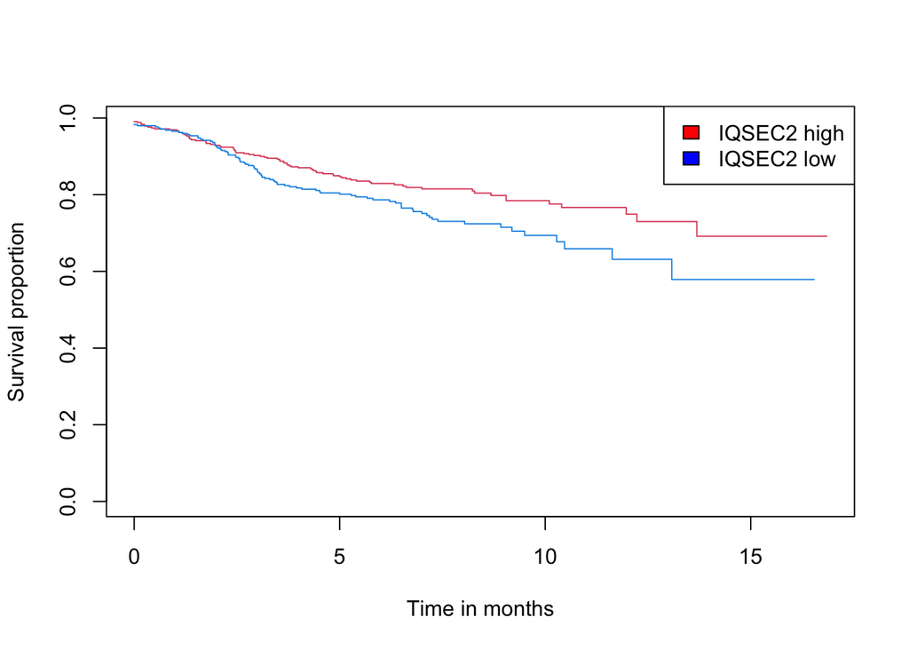

```r
plot( survfit( Surv(sampleDataop$dmfsTime, sampleDataop$dmfsEvent) ~ IQSEC2pif ),
xlab = "Time in months", ylab = "Survival proportion", col = c(2,4))
legend('topright', c("IQSEC2 high", "IQSEC2 low"), fill = c('red', 'blue'))
```

```r
IQSEC2nif = ifelse( expDaton["IQSEC2",] > mean(expDaton["IQSEC2",]), 1, 0)
table(IQSEC2nif)
```

```
## IQSEC2nif
##  0  1
## 19 23
```

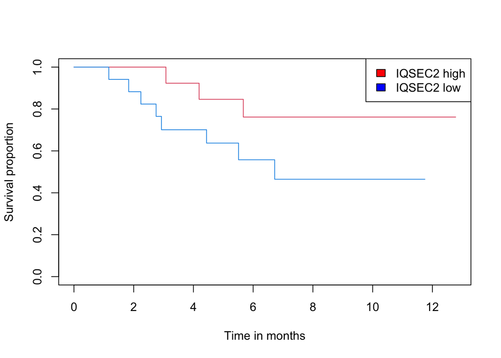

```r
plot( survfit( Surv(sampleDataon$dssTime, sampleDataon$dssEvent) ~ IQSEC2nif ),
xlab = "Time in months", ylab = "Survival proportion", col = c(2,4))
legend('topright', c("IQSEC2 high", "IQSEC2 low"), fill = c('red', 'blue'))
```

```r
#plot( survfit( Surv(sampleData$dmfsTime, sampleData$dmfsEvent) ~ ift ),xlab = "Time in months", ylab = "Proportion disease-spread free", col = c(2,4))
#legend('topright', c("ER+", "ER-"), fill = c('red', 'blue'))



#median(CD163)

#CDhigh = CD163[CD163>3.1025,]
#CDlow = CD163[CD163<3.1025,]


CDpif = ifelse( expDatop["CD163",] > median(expDatop["CD163",]), 1, 0)
table(CDpif)
```

```
## CDpif
##   0   1
## 398 393
```

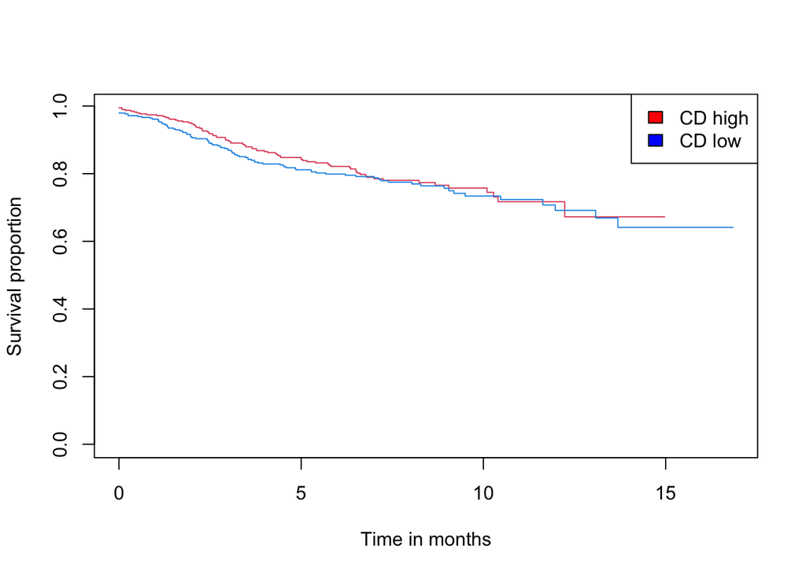

```r
plot( survfit( Surv(sampleDataop$dmfsTime, sampleDataop$dmfsEvent) ~ CDpif ),
xlab = "Time in months", ylab = "Survival proportion", col = c(2,4))
legend('topright', c("CD high", "CD low"), fill = c('red', 'blue'))
```

```r
CDnif = ifelse( expDaton["CD163",] > median(expDaton["CD163",]), 1, 0)
table(CDnif)
```

```
## CDnif
##  0  1
## 21 21
```

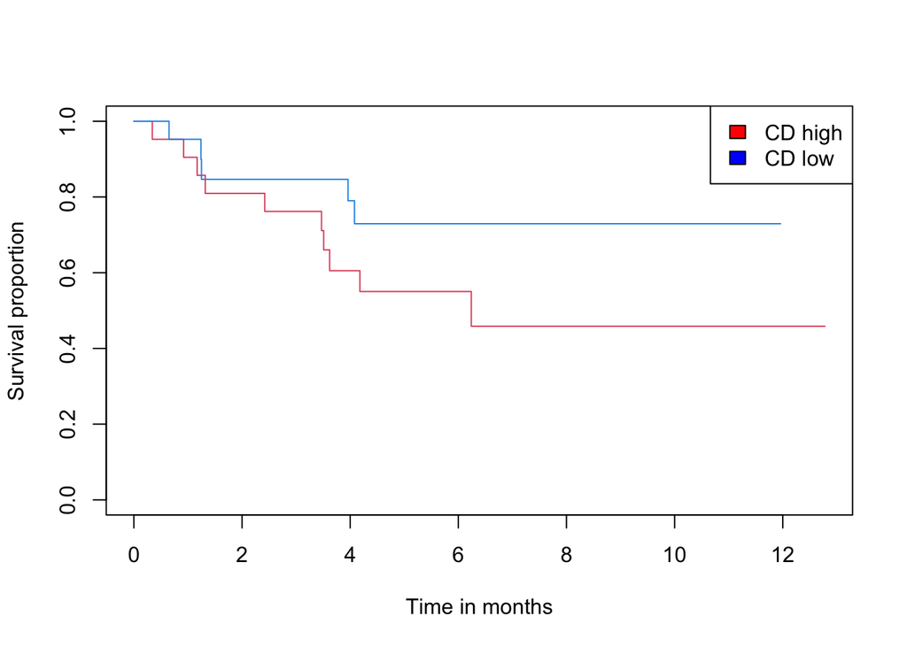

```r
plot( survfit( Surv(sampleDataon$dmfsTime, sampleDataon$dmfsEvent) ~ CDnif ),
xlab = "Time in months", ylab = "Survival proportion", col = c(2,4))
legend('topright', c("CD high", "CD low"), fill = c('red', 'blue'))
```

```r
HIST1H2AJpif = ifelse( expDatop["HIST1H2AJ",] > mean(expDatop["HIST1H2AJ",]), 1, 0)
table(HIST1H2AJpif)
```

```
## HIST1H2AJpif
##   0   1
## 424 367
```

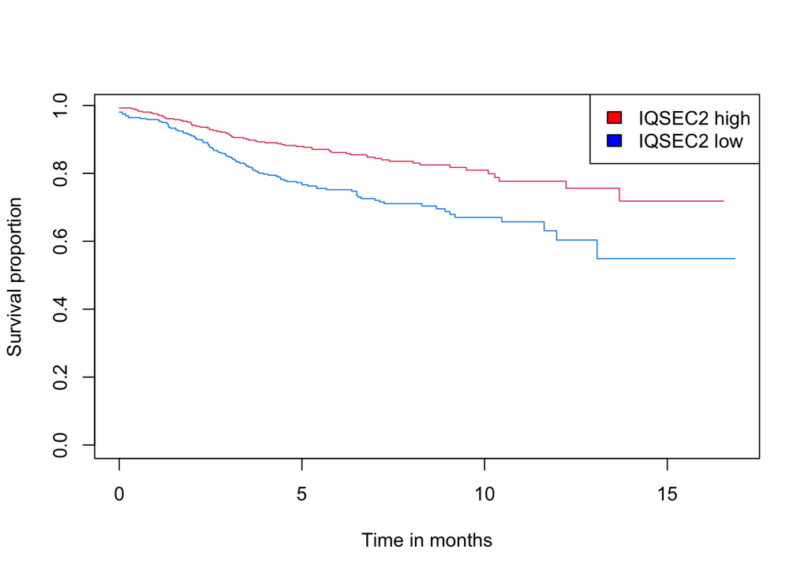

```r
plot( survfit( Surv(sampleDataop$dmfsTime, sampleDataop$dmfsEvent) ~ HIST1H2AJpif ),
xlab = "Time in months", ylab = "Survival proportion", col = c(2,4))
legend('topright', c("IQSEC2 high", "IQSEC2 low"), fill = c('red', 'blue'))
```

```r
HIST1H2AJnif = ifelse( expDaton["HIST1H2AJ",] > mean(expDaton["HIST1H2AJ",]), 1, 0)
table(HIST1H2AJnif)
```

```
## HIST1H2AJnif
##  0  1
## 23 19
```

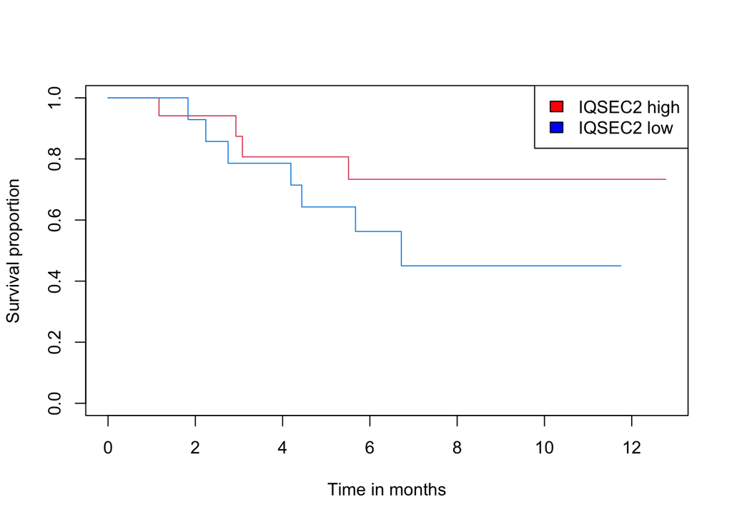

```r
plot( survfit( Surv(sampleDataon$dssTime, sampleDataon$dssEvent) ~ HIST1H2AJnif ),
xlab = "Time in months", ylab = "Survival proportion", col = c(2,4))
legend('topright', c("IQSEC2 high", "IQSEC2 low"), fill = c('red', 'blue'))
```

```r
CXCL13pif = ifelse( expDatop["CXCL13",] > mean(expDatop["CXCL13",]), 1, 0)
table(CXCL13pif)
```

```
## CXCL13pif
##   0   1
## 500 291
```

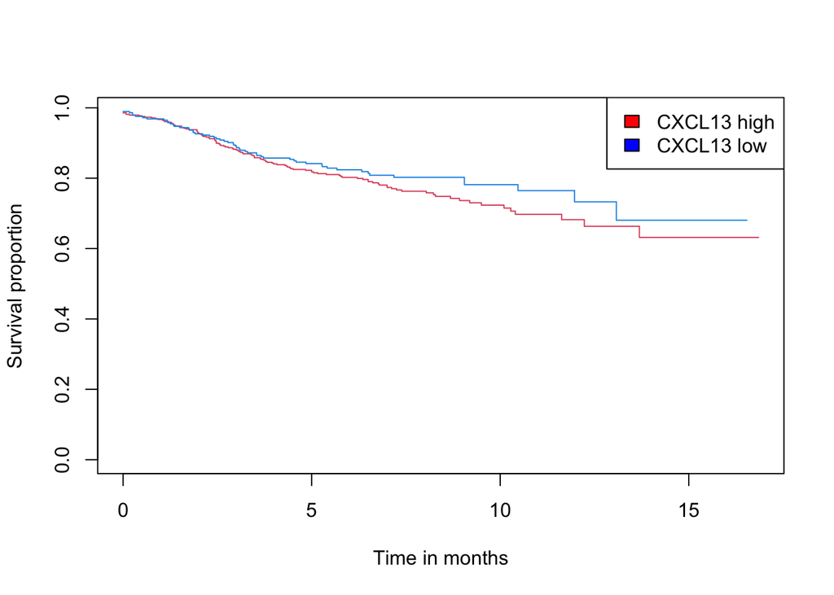

```r
plot( survfit( Surv(sampleDataop$dmfsTime, sampleDataop$dmfsEvent) ~ CXCL13pif ),
xlab = "Time in months", ylab = "Survival proportion", col = c(2,4))
legend('topright', c("CXCL13 high", "CXCL13 low"), fill = c('red', 'blue'))
```

```r
CXCL13nif = ifelse( expDaton["CXCL13",] > mean(expDaton["CXCL13",]), 1, 0)
table(CXCL13nif)
```

```
## CXCL13nif
##  0  1
## 18 24
```

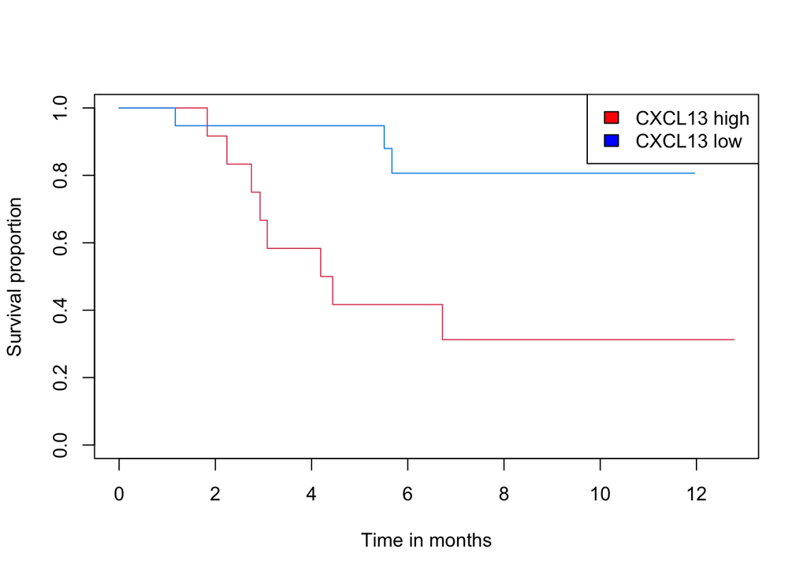

```r
plot( survfit( Surv(sampleDataon$dssTime, sampleDataon$dssEvent) ~ CXCL13nif ),
xlab = "Time in months", ylab = "Survival proportion", col = c(2,4))
legend('topright', c("CXCL13 high", "CXCL13 low"), fill = c('red', 'blue'))
```

```r
CXCL13nif
```

```
##   GSM79117   GSM79148   GSM79191   GSM79195   GSM79239   GSM79259   GSM79274
##          1          1          1          1          1          0          0
##   GSM79292   GSM79341   GSM79351  GSM107082  GSM107131  GSM107166  GSM107183
##          1          1          1          1          1          0          1
##    OXF5431    OXF5432    OXF5440    OXF5444    OXF5448    OXF5451    OXF5460
##          0          0          0          0          1          0          1
##    OXF5466   GSM50045   GSM50048   GSM50054   GSM50060   GSM50061   GSM50066
##          1          0          0          1          1          1          0
##   GSM50071   GSM50093   GSM50116 1639356696 1639355859 1639356632 1639357580
##          0          0          0          0          1          1          1
## 1639355773 1639357556 1639356846 1639358104 1639355985 1639356292 1639357162
##          0          1          1          1          1          0          0
```

```r
STX8pif = ifelse( expDatop["STX8",] > mean(expDatop["STX8",]), 1, 0)
table(STX8pif)
```

```
## STX8pif
##   0   1
## 393 398
```

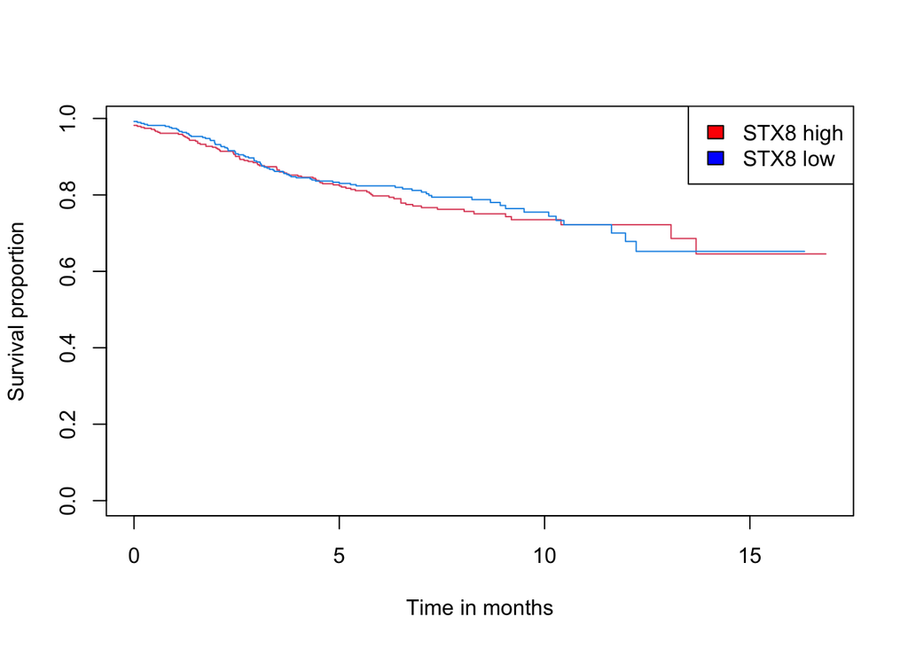

```r
plot( survfit( Surv(sampleDataop$dmfsTime, sampleDataop$dmfsEvent) ~ STX8pif ),
xlab = "Time in months", ylab = "Survival proportion", col = c(2,4))
legend('topright', c("STX8 high", "STX8 low"), fill = c('red', 'blue'))
```

```r
STX8nif = ifelse( expDaton["STX8",] > mean(expDaton["STX8",]), 1, 0)
table(STX8nif)
```

```
## STX8nif
##  0  1
## 22 20
```

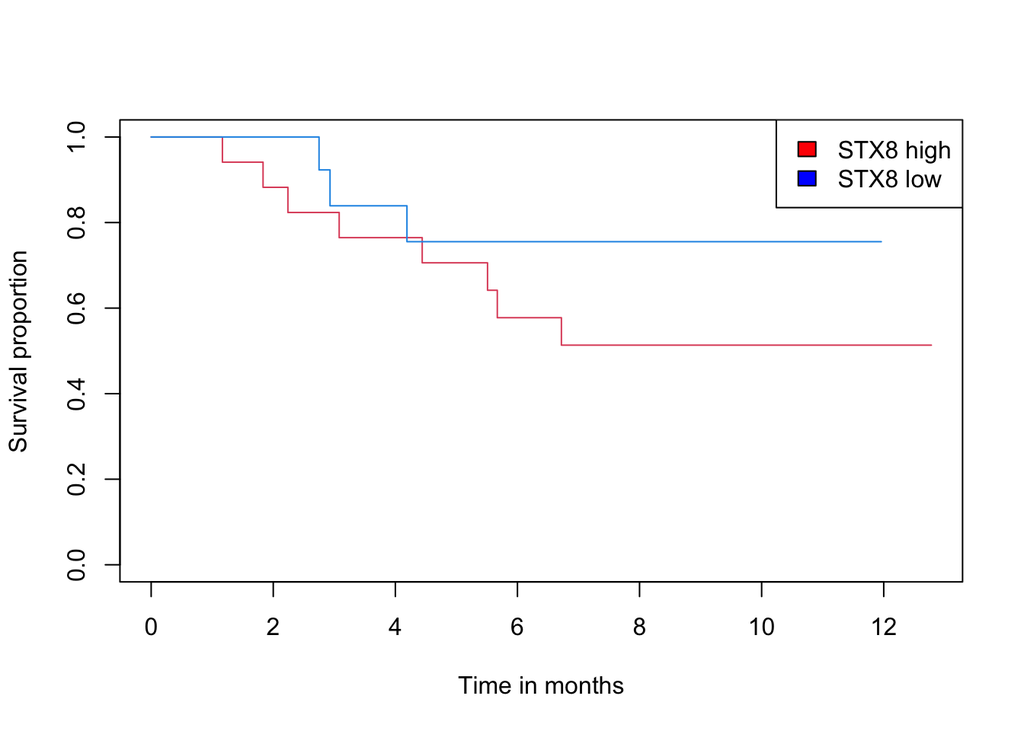

```r
plot( survfit( Surv(sampleDataon$dssTime, sampleDataon$dssEvent) ~ STX8nif ),
xlab = "Time in months", ylab = "Survival proportion", col = c(2,4))
legend('topright', c("STX8 high", "STX8 low"), fill = c('red', 'blue'))
```

```r
TIMM22pif = ifelse( expDatop["TIMM22",] > mean(expDatop["TIMM22",]), 1, 0)
table(TIMM22pif)
```

```
## TIMM22pif
##   0   1
## 420 371
```

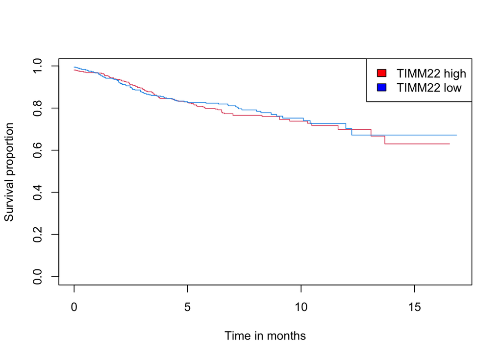

```r
plot( survfit( Surv(sampleDataop$dmfsTime, sampleDataop$dmfsEvent) ~ TIMM22pif ),
xlab = "Time in months", ylab = "Survival proportion", col = c(2,4))
legend('topright', c("TIMM22 high", "TIMM22 low"), fill = c('red', 'blue'))
```

```r
TIMM22nif = ifelse( expDaton["TIMM22",] > mean(expDaton["TIMM22",]), 1, 0)
table(TIMM22nif)
```

```
## TIMM22nif
##  0  1
## 25 17
```

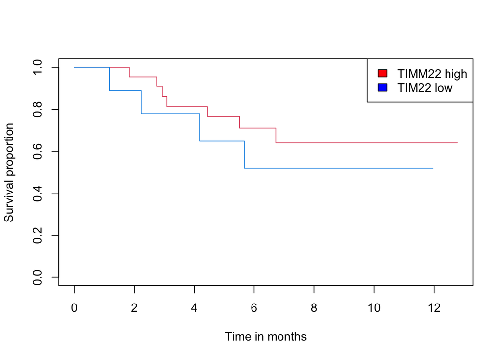

```r
plot( survfit( Surv(sampleDataon$dssTime, sampleDataon$dssEvent) ~ TIMM22nif ),
xlab = "Time in months", ylab = "Survival proportion", col = c(2,4))
legend('topright', c("TIMM22 high", "TIM22 low"), fill = c('red', 'blue'))
```

```r
ARHGEF7pif = ifelse( expDatop["ARHGEF7",] > mean(expDatop["ARHGEF7",]), 1, 0)
table(ARHGEF7pif)
```

```
## ARHGEF7pif
##   0   1
## 378 413
```

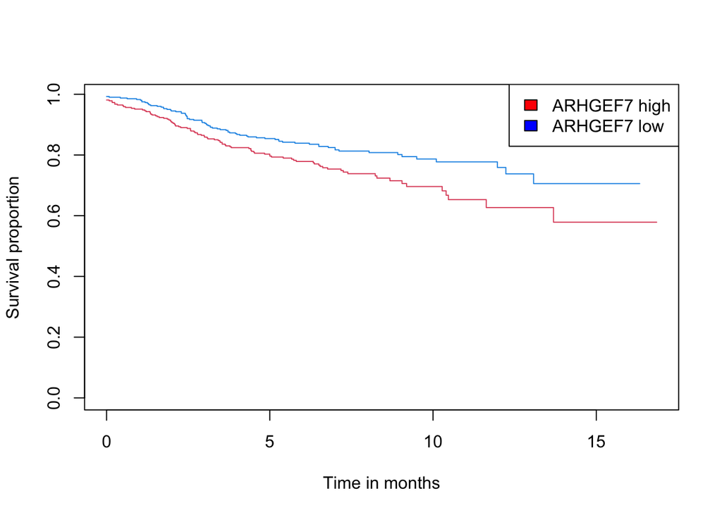

```r
plot( survfit( Surv(sampleDataop$dmfsTime, sampleDataop$dmfsEvent) ~ ARHGEF7pif ),
xlab = "Time in months", ylab = "Survival proportion", col = c(2,4))
legend('topright', c("ARHGEF7 high", "ARHGEF7 low"), fill = c('red', 'blue'))
```

```r
ARHGEF7nif = ifelse( expDaton["ARHGEF7",] > mean(expDaton["ARHGEF7",]), 1, 0)
table(ARHGEF7nif)
```

```
## ARHGEF7nif
##  0  1
## 19 23
```

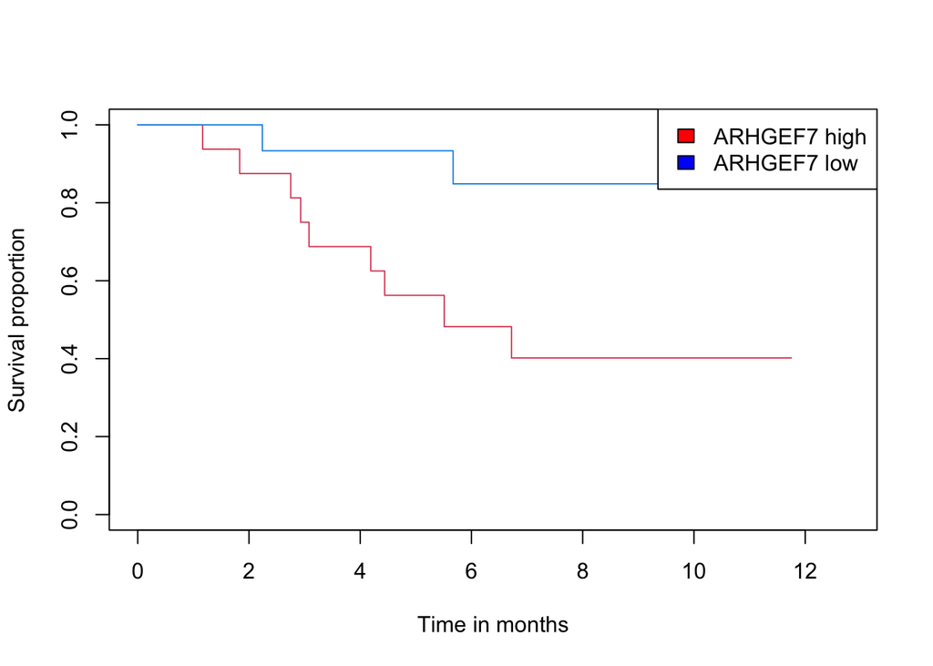

```r
plot( survfit( Surv(sampleDataon$dssTime, sampleDataon$dssEvent) ~ ARHGEF7nif ),
xlab = "Time in months", ylab = "Survival proportion", col = c(2,4))
legend('topright', c("ARHGEF7 high", "ARHGEF7 low"), fill = c('red', 'blue'))
```

```r
MKRN2pif = ifelse( expDatop["MKRN2",] > mean(expDatop["MKRN2",]), 1, 0)
table(MKRN2pif)
```

```
## MKRN2pif
##   0   1
## 410 381
```

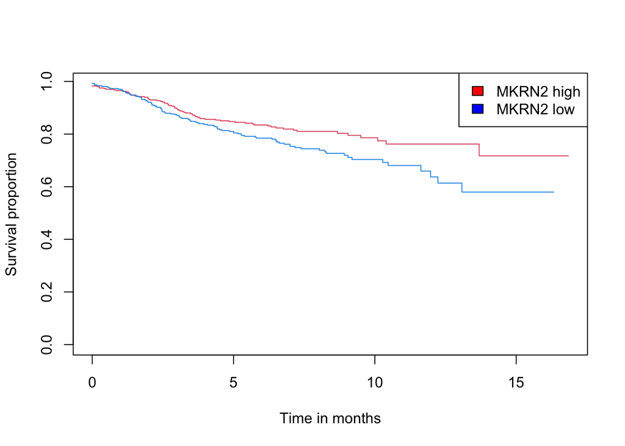

```r
plot( survfit( Surv(sampleDataop$dmfsTime, sampleDataop$dmfsEvent) ~ MKRN2pif ),
xlab = "Time in months", ylab = "Survival proportion", col = c(2,4))
legend('topright', c("MKRN2 high", "MKRN2 low"), fill = c('red', 'blue'))
```

```r
MKRN2nif = ifelse( expDaton["MKRN2",] > mean(expDaton["MKRN2",]), 1, 0)
table(MKRN2nif)
```

```
## MKRN2nif
##  0  1
## 25 17
```

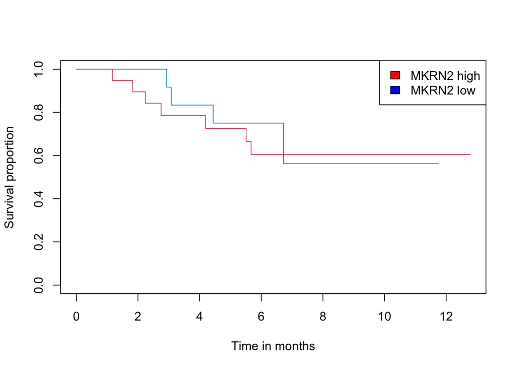

```r
plot( survfit( Surv(sampleDataon$dssTime, sampleDataon$dssEvent) ~ MKRN2nif ),
xlab = "Time in months", ylab = "Survival proportion", col = c(2,4))
legend('topright', c("MKRN2 high", "MKRN2 low"), fill = c('red', 'blue'))
```

```r
PARP3pif = ifelse( expDatop["PARP3",] > mean(expDatop["PARP3",]), 1, 0)
table(PARP3pif)
```

```
## PARP3pif
##   0   1
## 405 386
```

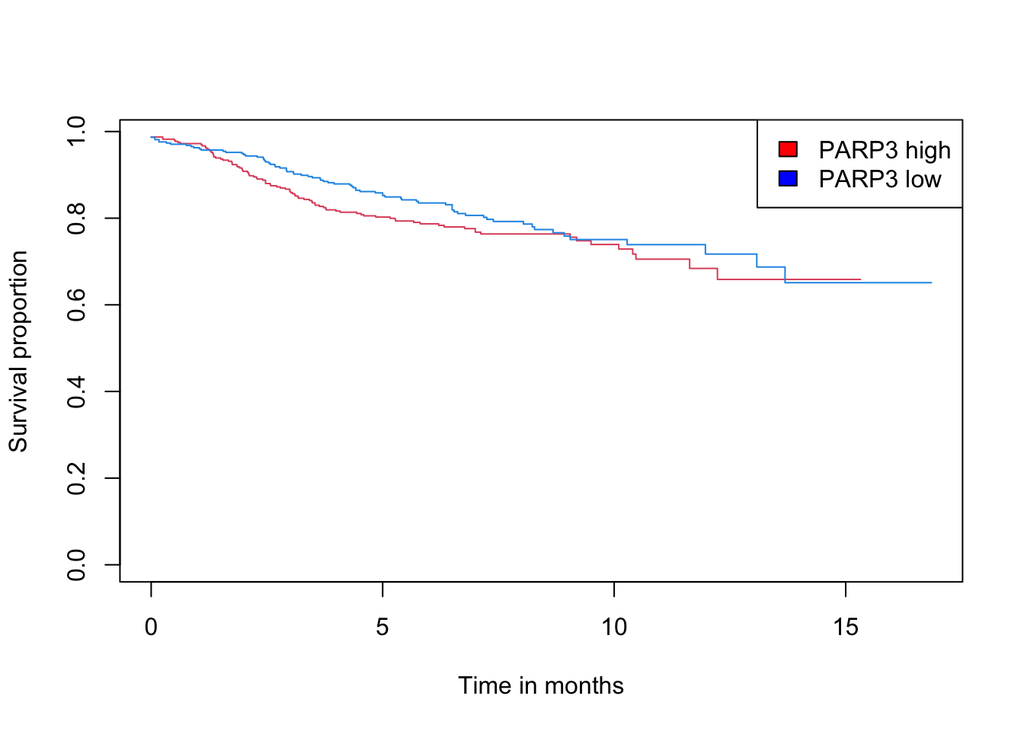

```r
plot( survfit( Surv(sampleDataop$dmfsTime, sampleDataop$dmfsEvent) ~ PARP3pif ),
xlab = "Time in months", ylab = "Survival proportion", col = c(2,4))
legend('topright', c("PARP3 high", "PARP3 low"), fill = c('red', 'blue'))
```

```r
PARP3nif = ifelse( expDaton["PARP3",] > mean(expDaton["PARP3",]), 1, 0)
table(PARP3nif)
```

```
## PARP3nif
##  0  1
## 18 24
```

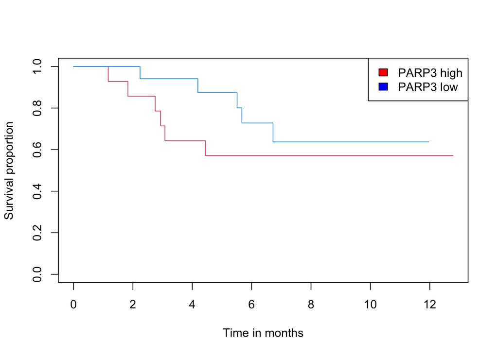

```r
plot( survfit( Surv(sampleDataon$dssTime, sampleDataon$dssEvent) ~ PARP3nif ),
xlab = "Time in months", ylab = "Survival proportion", col = c(2,4))
legend('topright', c("PARP3 high", "PARP3 low"), fill = c('red', 'blue'))
```

```r
DHRS12pif = ifelse( expDatop["DHRS12",] > mean(expDatop["DHRS12",]), 1, 0)
table(DHRS12pif)
```

```
## DHRS12pif
##   0   1
## 414 377
```

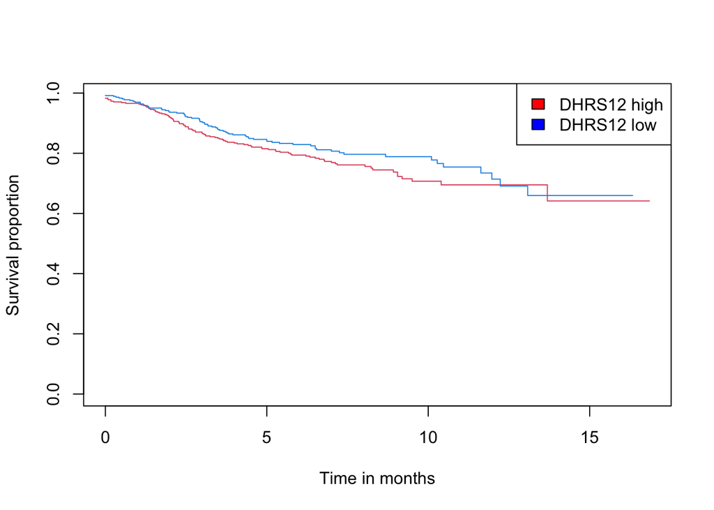

```r
plot( survfit( Surv(sampleDataop$dmfsTime, sampleDataop$dmfsEvent) ~ DHRS12pif ),
xlab = "Time in months", ylab = "Survival proportion", col = c(2,4))
legend('topright', c("DHRS12 high", "DHRS12 low"), fill = c('red', 'blue'))
```

```r
DHRS12nif = ifelse( expDaton["DHRS12",] > mean(expDaton["DHRS12",]), 1, 0)
table(DHRS12nif)
```

```
## DHRS12nif
##  0  1
## 24 18
```

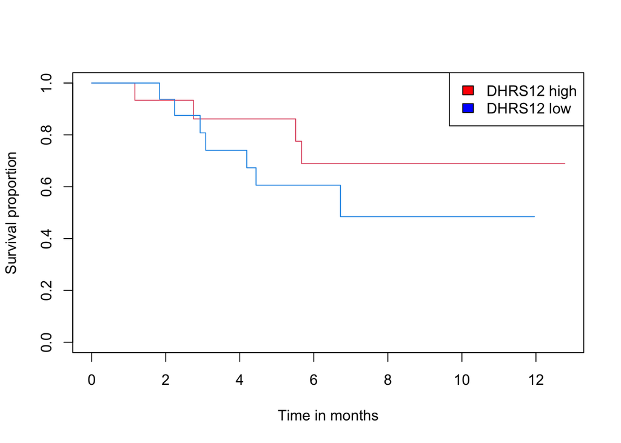

```r
plot( survfit( Surv(sampleDataon$dssTime, sampleDataon$dssEvent) ~ DHRS12nif ),
xlab = "Time in months", ylab = "Survival proportion", col = c(2,4))
legend('topright', c("DHRS12 high", "DHRS12 low"), fill = c('red', 'blue'))
```

```r
CXCL13nif
```

```
##   GSM79117   GSM79148   GSM79191   GSM79195   GSM79239   GSM79259   GSM79274
##          1          1          1          1          1          0          0
##   GSM79292   GSM79341   GSM79351  GSM107082  GSM107131  GSM107166  GSM107183
##          1          1          1          1          1          0          1
##    OXF5431    OXF5432    OXF5440    OXF5444    OXF5448    OXF5451    OXF5460
##          0          0          0          0          1          0          1
##    OXF5466   GSM50045   GSM50048   GSM50054   GSM50060   GSM50061   GSM50066
##          1          0          0          1          1          1          0
##   GSM50071   GSM50093   GSM50116 1639356696 1639355859 1639356632 1639357580
##          0          0          0          0          1          1          1
## 1639355773 1639357556 1639356846 1639358104 1639355985 1639356292 1639357162
##          0          1          1          1          1          0          0
```

```r
FBXO34pif = ifelse( expDatop["FBXO34",] > mean(expDatop["FBXO34",]), 1, 0)
table(FBXO34pif)
```

```
## FBXO34pif
##   0   1
## 388 403
```

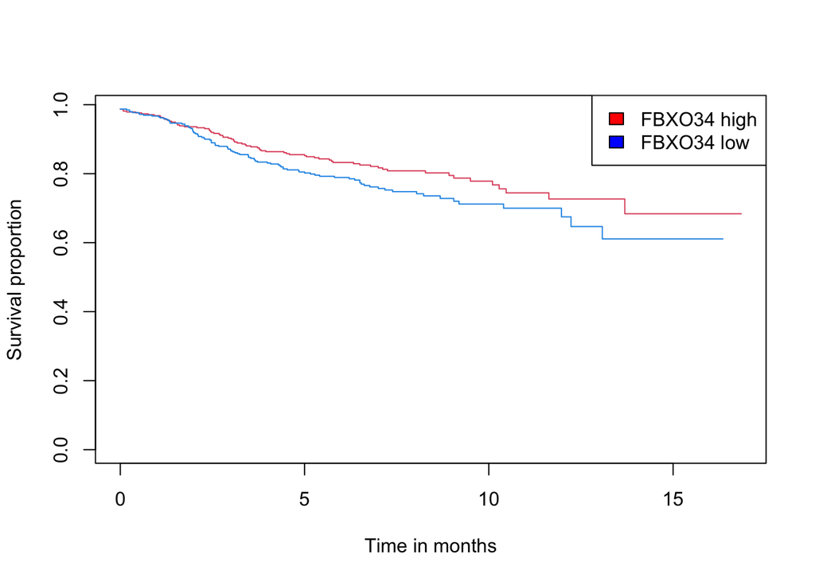

```r
plot( survfit( Surv(sampleDataop$dmfsTime, sampleDataop$dmfsEvent) ~ FBXO34pif ),
xlab = "Time in months", ylab = "Survival proportion", col = c(2,4))
legend('topright', c("FBXO34 high", "FBXO34 low"), fill = c('red', 'blue'))
```

```r
FBXO34nif = ifelse( expDaton["FBXO34",] > mean(expDaton["FBXO34",]), 1, 0)
table(FBXO34nif)
```

```
## FBXO34nif
##  0  1
## 21 21
```

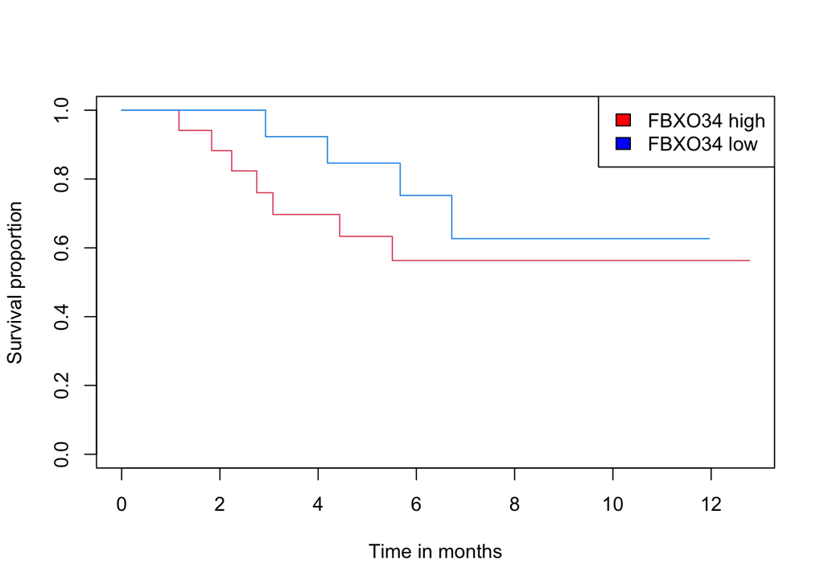

```r
plot( survfit( Surv(sampleDataon$dssTime, sampleDataon$dssEvent) ~ FBXO34nif ),
xlab = "Time in months", ylab = "Survival proportion", col = c(2,4))
legend('topright', c("FBXO34 high", "FBXO34 low"), fill = c('red', 'blue'))
```

```r
CXCL13nif
```

```
##   GSM79117   GSM79148   GSM79191   GSM79195   GSM79239   GSM79259   GSM79274
##          1          1          1          1          1          0          0
##   GSM79292   GSM79341   GSM79351  GSM107082  GSM107131  GSM107166  GSM107183
##          1          1          1          1          1          0          1
##    OXF5431    OXF5432    OXF5440    OXF5444    OXF5448    OXF5451    OXF5460
##          0          0          0          0          1          0          1
##    OXF5466   GSM50045   GSM50048   GSM50054   GSM50060   GSM50061   GSM50066
##          1          0          0          1          1          1          0
##   GSM50071   GSM50093   GSM50116 1639356696 1639355859 1639356632 1639357580
##          0          0          0          0          1          1          1
## 1639355773 1639357556 1639356846 1639358104 1639355985 1639356292 1639357162
##          0          1          1          1          1          0          0
```

```r
IL21pif = ifelse( expDatop["IL21",] > mean(expDatop["IL21",]), 1, 0)
table(IL21pif)
```

```
## IL21pif
##   0   1
## 430 361
```

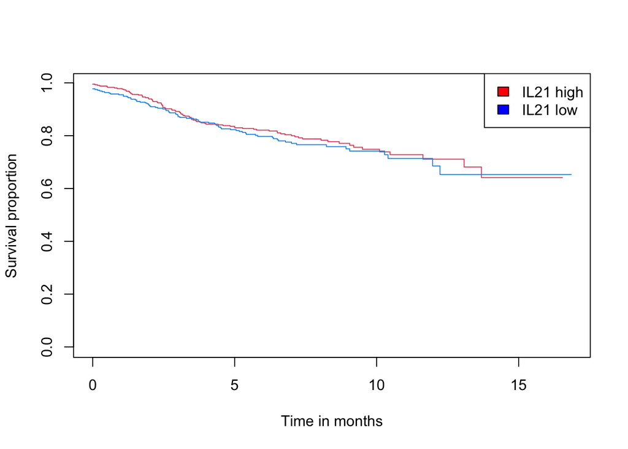

```r
plot( survfit( Surv(sampleDataop$dmfsTime, sampleDataop$dmfsEvent) ~ IL21pif ),
xlab = "Time in months", ylab = "Survival proportion", col = c(2,4))
legend('topright', c("IL21 high", "IL21 low"), fill = c('red', 'blue'))
```

```r
IL21nif = ifelse( expDaton["IL21",] > mean(expDaton["IL21",]), 1, 0)
table(IL21nif)
```

```
## IL21nif
##  0  1
## 24 18
```

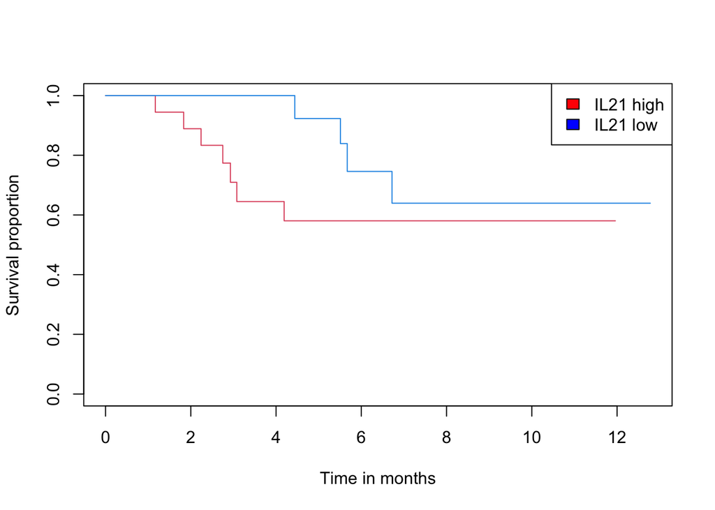

```r
plot( survfit( Surv(sampleDataon$dssTime, sampleDataon$dssEvent) ~ IL21nif ),
xlab = "Time in months", ylab = "Survival proportion", col = c(2,4))
legend('topright', c("IL21 high", "IL21 low"), fill = c('red', 'blue'))
```

```r
CXCL13nif
```

```
##   GSM79117   GSM79148   GSM79191   GSM79195   GSM79239   GSM79259   GSM79274
##          1          1          1          1          1          0          0
##   GSM79292   GSM79341   GSM79351  GSM107082  GSM107131  GSM107166  GSM107183
##          1          1          1          1          1          0          1
##    OXF5431    OXF5432    OXF5440    OXF5444    OXF5448    OXF5451    OXF5460
##          0          0          0          0          1          0          1
##    OXF5466   GSM50045   GSM50048   GSM50054   GSM50060   GSM50061   GSM50066
##          1          0          0          1          1          1          0
##   GSM50071   GSM50093   GSM50116 1639356696 1639355859 1639356632 1639357580
##          0          0          0          0          1          1          1
## 1639355773 1639357556 1639356846 1639358104 1639355985 1639356292 1639357162
##          0          1          1          1          1          0          0
```

```r
PTNpif = ifelse( expDatop["PTN",] > mean(expDatop["PTN",]), 1, 0)
table(PTNpif)
```

```
## PTNpif
##   0   1
## 511 280
```

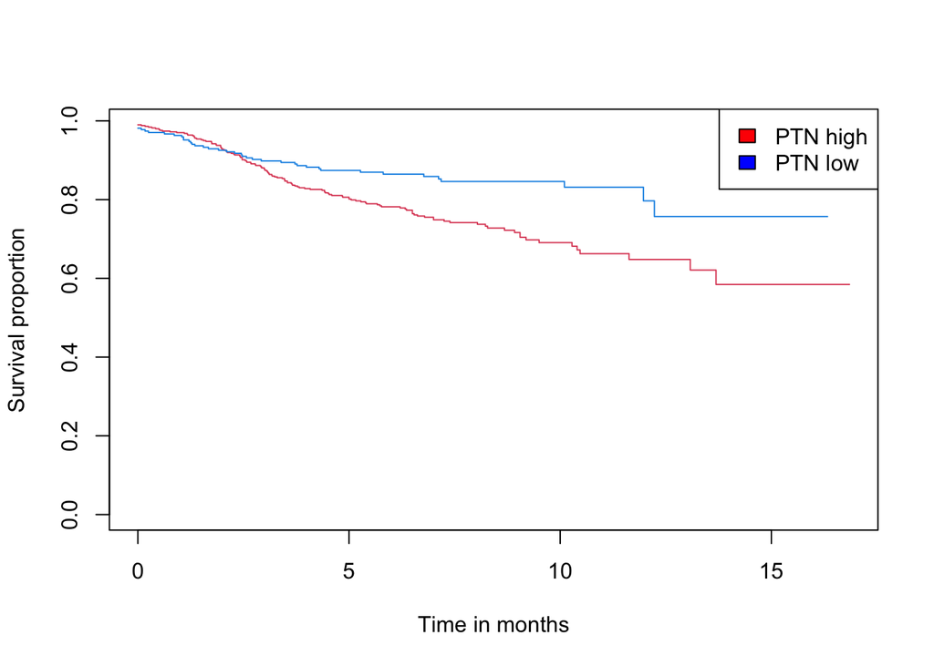

```r
plot( survfit( Surv(sampleDataop$dmfsTime, sampleDataop$dmfsEvent) ~ PTNpif ),
xlab = "Time in months", ylab = "Survival proportion", col = c(2,4))
legend('topright', c("PTN high", "PTN low"), fill = c('red', 'blue'))
```

```r
PTNnif = ifelse( expDaton["PTN",] > mean(expDaton["PTN",]), 1, 0)
table(PTNnif)
```

```
## PTNnif
##  0  1
## 31 11
```

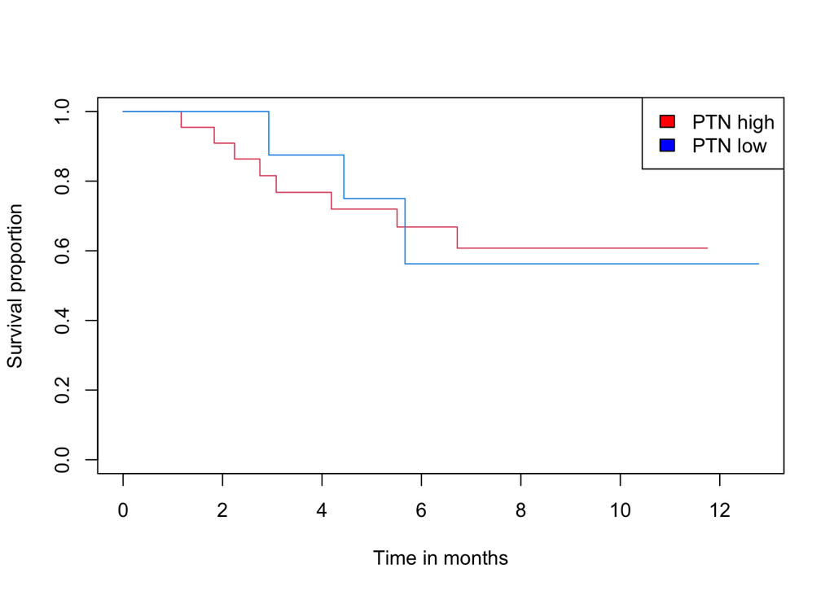

```r
plot( survfit( Surv(sampleDataon$dssTime, sampleDataon$dssEvent) ~ PTNnif ),
xlab = "Time in months", ylab = "Survival proportion", col = c(2,4))
legend('topright', c("PTN high", "PTN low"), fill = c('red', 'blue'))
```

```r
SLC4A1pif = ifelse( expDatop["SLC4A1",] > mean(expDatop["SLC4A1",]), 1, 0)
table(SLC4A1pif)
```

```
## SLC4A1pif
##   0   1
## 430 361
```

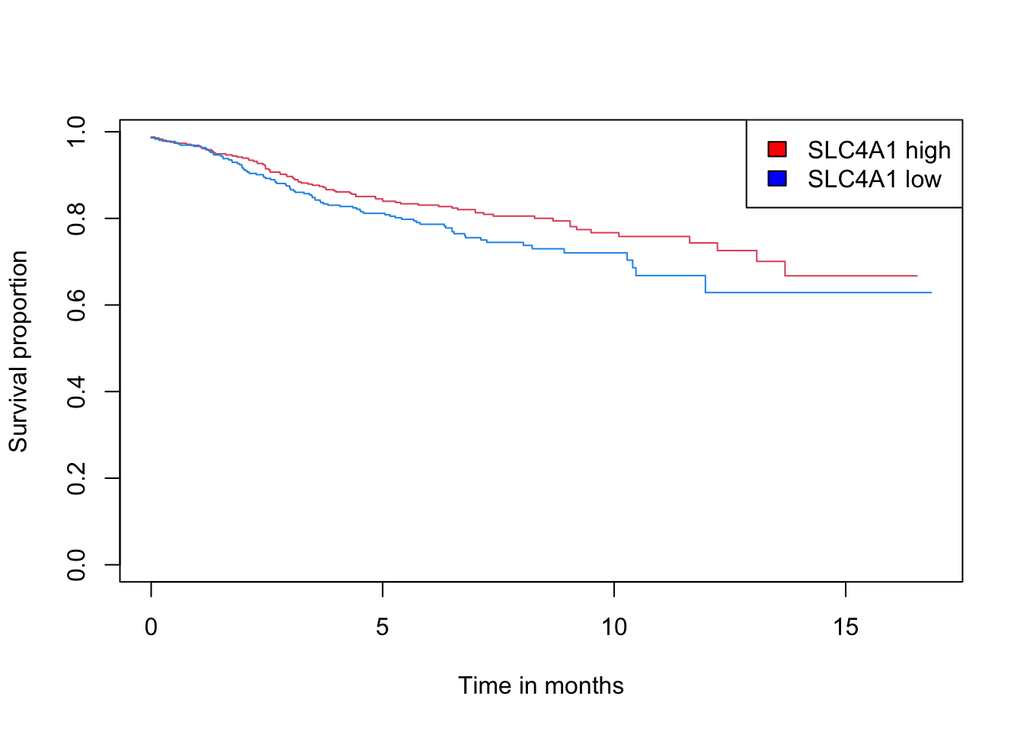

```r
plot( survfit( Surv(sampleDataop$dmfsTime, sampleDataop$dmfsEvent) ~ SLC4A1pif ),
xlab = "Time in months", ylab = "Survival proportion", col = c(2,4))
legend('topright', c("SLC4A1 high", "SLC4A1 low"), fill = c('red', 'blue'))
```

```r
SLC4A1nif = ifelse( expDaton["SLC4A1",] > mean(expDaton["SLC4A1",]), 1, 0)
table(SLC4A1nif)
```

```
## SLC4A1nif
##  0  1
## 23 19
```

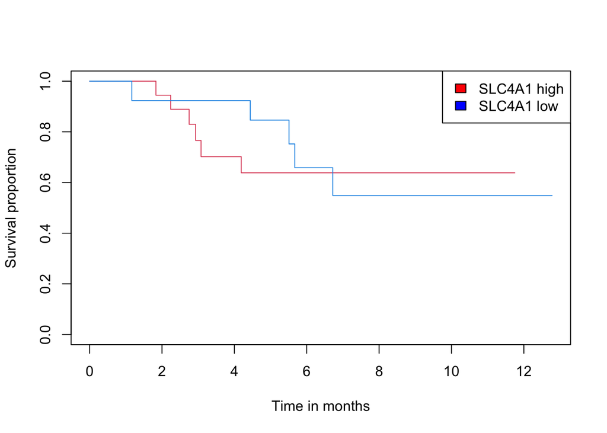

```r
plot( survfit( Surv(sampleDataon$dssTime, sampleDataon$dssEvent) ~ SLC4A1nif ),
xlab = "Time in months", ylab = "Survival proportion", col = c(2,4))
legend('topright', c("SLC4A1 high", "SLC4A1 low"), fill = c('red', 'blue'))
```

```r
MBpif = ifelse( expDatop["MB",] > mean(expDatop["MB",]), 1, 0)
table(MBpif)
```

```
## MBpif
##   0   1
## 411 380
```

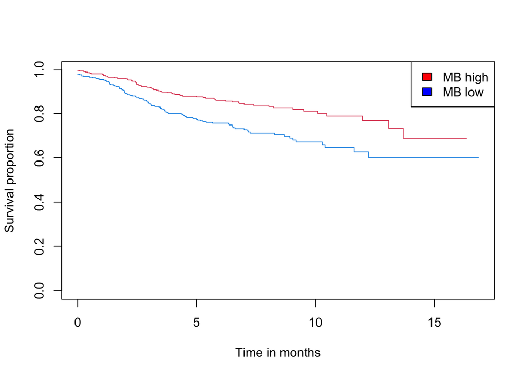

```r
plot( survfit( Surv(sampleDataop$dmfsTime, sampleDataop$dmfsEvent) ~ MBpif ),
xlab = "Time in months", ylab = "Survival proportion", col = c(2,4))
legend('topright', c("MB high", "MB low"), fill = c('red', 'blue'))
```

```r
MBnif = ifelse( expDaton["MB",] > mean(expDaton["MB",]), 1, 0)
table(MBnif)
```

```
## MBnif
##  0  1
## 24 18
```

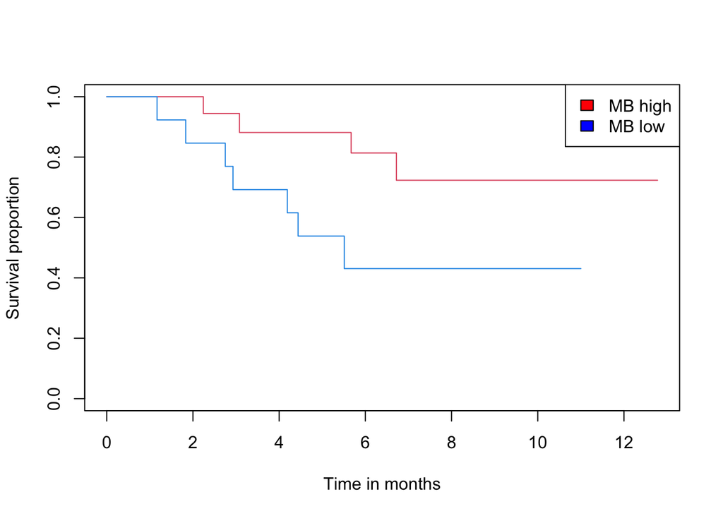

```r
plot( survfit( Surv(sampleDataon$dssTime, sampleDataon$dssEvent) ~ MBnif ),
xlab = "Time in months", ylab = "Survival proportion", col = c(2,4))
legend('topright', c("MB high", "MB low"), fill = c('red', 'blue'))
```

```r
KIR2DL4pif = ifelse( expDatop["KIR2DL4",] > mean(expDatop["KIR2DL4",]), 1, 0)
table(KIR2DL4pif)
```

```
## KIR2DL4pif
##   0   1
## 412 379
```

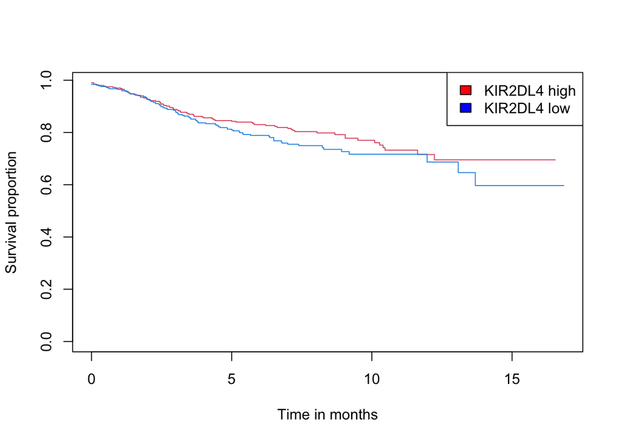

```r
plot( survfit( Surv(sampleDataop$dmfsTime, sampleDataop$dmfsEvent) ~ KIR2DL4pif ),
xlab = "Time in months", ylab = "Survival proportion", col = c(2,4))
legend('topright', c("KIR2DL4 high", "KIR2DL4 low"), fill = c('red', 'blue'))
```

```r
KIR2DL4nif = ifelse( expDaton["KIR2DL4",] > mean(expDaton["KIR2DL4",]), 1, 0)
table(KIR2DL4nif)
```

```
## KIR2DL4nif
##  0  1
## 22 20
```

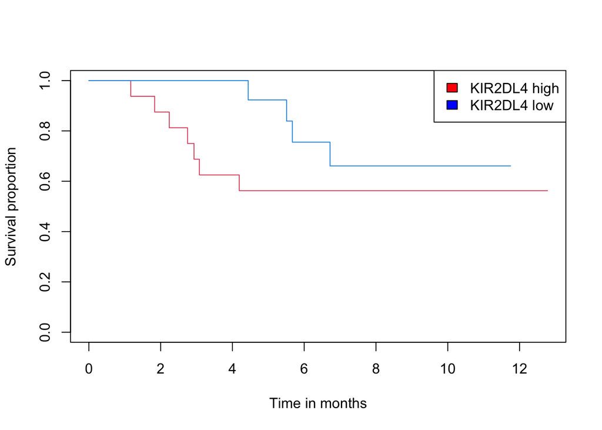

```r
plot( survfit( Surv(sampleDataon$dssTime, sampleDataon$dssEvent) ~ KIR2DL4nif ),
xlab = "Time in months", ylab = "Survival proportion", col = c(2,4))
legend('topright', c("KIR2DL4 high", "KIR2DL4 low"), fill = c('red', 'blue'))
```